# Analysis

# 1 Data loadind and cleaning

Load the data

```r
tdata <- read_csv("exp_data.csv")
```

Exclude data from subjects who failed the check questions (attention, learning, comprehension, etc.)

```r
# Exclude subjects who failed the control questions
tdata <- subset(tdata, confirmations_correct == "correct")
tdata <- subset(tdata, intro_check_correct == "correct")
tdata <- subset(tdata, learn_check_correct == "correct")
tdata <- subset(tdata, learn_check_structure_correct == "correct")
tdata <- subset(tdata, timing_check_correct == "correct")
```

```r
table(tdata$structure, tdata$first_object)
```

```
##
##              left right
##   reversible   25    25
##   stable       25    25
##   unstable     25    25
```

Table shows that the admired sample sizes (N = 150, n = 25 per group) were reached.

# 2 Subject demographics

```r
# demographics

min(tdata$age)
```

```
## [1] 18
```

```r
max(tdata$age)
```

```
## [1] 79
```

```r
mean(tdata$age)
```

```
## [1] 38.47333
```

```r
sd(tdata$age)
```

```
## [1] 12.66486
```

```r
# 1 = male, 2 = female, 3 = other
table(tdata$gender)
```

```
##
##       1: male     2: female 3: non-binary
##            66            82             2
```

1 = male, 2 = female, 3 = non-binary, 4 = prefer not to say

# 3 Data preparations

Factorize:

```r
tdata$structure <- factor(tdata$structure, levels = c("stable", "reversible", "unstable"),
                          labels = c("one-shot", "demarcating and reversible", "demarcating and irreversible"))
```

Relabel rating columns for the two causes according to “first object” (so that they are called first_obj_rating and second_obj_rating):

```r
left_first <- subset(tdata, first_object == "left")
colnames(left_first)[16] ="first_obj_caused_rating"
colnames(left_first)[17] ="second_obj_caused_rating"
colnames(left_first)[18] ="first_obj_maintained_rating"
colnames(left_first)[19] ="second_obj_maintained_rating"

right_first <- subset(tdata, first_object == "right")
colnames(right_first)[17] ="first_obj_caused_rating"
colnames(right_first)[16] ="second_obj_caused_rating"
colnames(right_first)[19] ="first_obj_maintained_rating"
colnames(right_first)[18] ="second_obj_maintained_rating"

right_first <- right_first[c("subj_code", "condition", "desktop_conf", "attent_conf", "confirmations_correct", "intro_check", "intro_check_correct",
                             "structure", "first_object", "learn_check_left", "learn_check_left_correct", "learn_check_right", "learn_check_right_correct",
                             "learn_check_structure", "learn_check_structure_correct",
                             "first_obj_caused_rating", "second_obj_caused_rating", "first_obj_maintained_rating", "second_obj_maintained_rating",
                             "timing_check", "timing_check_correct", "recorded_at",
                             "age", "gender", "tech_issues",
                             "learn_check_correct")]


names(left_first) %in% names(right_first)
```

```
##  [1] TRUE TRUE TRUE TRUE TRUE TRUE TRUE TRUE TRUE TRUE TRUE TRUE TRUE TRUE TRUE
## [16] TRUE TRUE TRUE TRUE TRUE TRUE TRUE TRUE TRUE TRUE TRUE
```

```r
tdata <- rbind(left_first, right_first)
```

Make a subset containing only the columns relevant for analyses and turn into long format:

```r
# Subset:
tdata_sub <- subset(tdata, select = c("subj_code","structure","first_obj_caused_rating", "second_obj_caused_rating",
                                      "first_obj_maintained_rating", "second_obj_maintained_rating"))

# into long format:
library(tidyr)
tdata_long <- gather(tdata_sub, entity, rating, 3:6)


# factorize entity
tdata_long$entity <- factor(tdata_long$entity, levels = c("first_obj_caused_rating", "second_obj_caused_rating",
                                                          "first_obj_maintained_rating", "second_obj_maintained_rating"),
                            labels = c("first \ntriggered", "second \ntriggered","first \nsustained", "second \nsustained"))

tdata_long$structure <- factor(tdata_long$structure, levels = c("one-shot", "demarcating and reversible", "demarcating and irreversible"))
```

# 4 Graphs and summaries

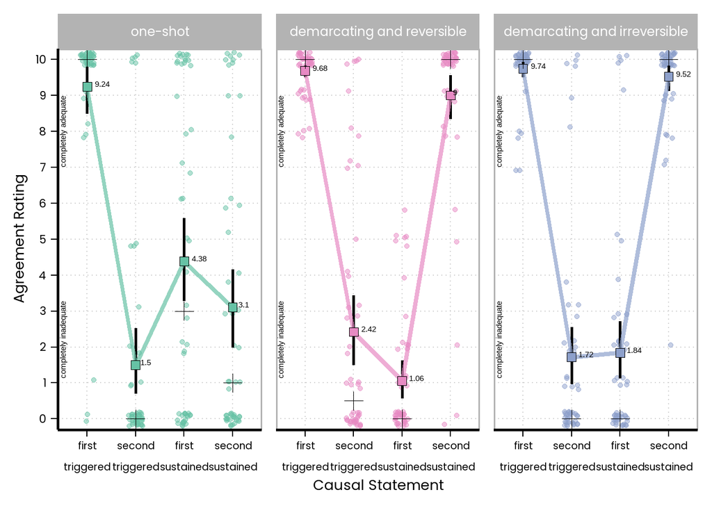

```r
myTheme <- theme(plot.title = element_text(face="bold", size = 22),
        axis.title.x = element_text(size = 20),
        axis.title.y = element_text(size = 20),
        axis.text.x = element_text(size = 14, angle = 0),
        axis.text.y = element_text(size = 16, angle = 0),
        legend.text = element_text(size = 18),
        legend.title = element_text(face = "bold", size = 18),
        strip.text.x = element_text(size = 18),
        panel.grid.major = element_blank(),
        panel.grid.minor = element_blank(),
        panel.background = element_blank(),
        axis.line.x = element_line(colour = "black"),
        axis.line.y = element_line(colour = "black"),
        axis.text = element_text(colour ="black"),
        axis.ticks = element_line(colour ="black"))


tdata_sub <- tdata_long


library(see)
## first, turn sID into a factor
tdata_sub$subj_code <- factor(tdata_sub$subj_code)

pd <- position_dodge(width = 0.3)

tdata_sub$valueJitter <- jitter(tdata_sub$rating, factor = 0.01, amount = 0.004)

theme_set(theme_light(base_size = 20, base_family = "Poppins"))


g <- ggplot(tdata_sub, aes(x = entity, y = valueJitter)) +
  guides(fill=FALSE)+
  facet_grid( ~ structure)+
  scale_y_continuous(limits = c(-0.3, 10.3), breaks=seq(0, 10, 1), expand = c(0,0)) +
  geom_jitter(aes(color = structure), alpha = 0.5, width = 0.15, height = 0.2) +
  stat_summary(aes(y = rating, group=1), fun.data = mean_cl_boot,
               geom = "errorbar", width = 0, size = 1) +
  stat_summary(aes(y = rating, group=1, color = structure), fun.y=mean, geom="line",
               shape = 22, size = 1.5, alpha = .7)+
  stat_summary(aes(y = rating, group=1, fill = structure), fun.y=mean, geom="point",
               color = "black", shape = 22, size = 3, group=1, alpha = 1)+
  stat_summary(aes(y = rating,group=1), fun.y=median, geom="point", color = "black", shape = 3, size = 4,
               group=1, alpha = 1, position = position_dodge(width = 0.5))+
  labs(x = "Causal Statement", y = "Agreement Rating") +
  scale_color_manual(name = "Strength",values=c("#66c2a5", "#e78ac3", "#8da0cb", "#a6d854"))+
  scale_fill_manual(name = "Strength",values=c("#66c2a5", "#e78ac3", "#8da0cb", "#a6d854"))+
  theme(legend.position = "none")+
  myTheme+
  theme(panel.grid.major = element_line(color = "lightgrey",
                                        size = 0.5,
                                        linetype = 'dotted'))+
  stat_summary(aes(label=round(after_stat(y),2)), fun.y=mean, geom="text", size=4,
             vjust = 0, hjust = -0.5)+
  annotate("text", x = 0.5, y = 2.2, label = c("completely inadequate"), angle = 90)+
  annotate("text", x = 0.5, y = 8.0, label = c("completely adequate"), angle = 90)

g
```

```r
ggsave("results_means_mainDV.svg",width=17,height=5)
ggsave("results_means_mainDV.pdf",width=17,height=5)
```

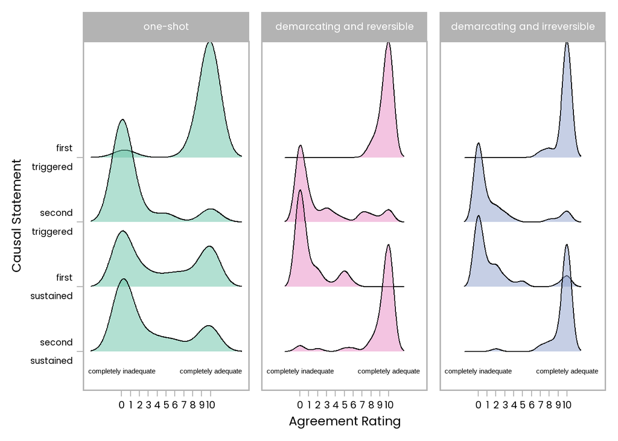

```r
library(ggridges)
g2 <- ggplot(tdata_long, aes(x = rating, y = entity, fill = structure)) +
  facet_grid( ~ structure)+
  scale_x_continuous(breaks = seq(0, 10, 1))+
  geom_density_ridges(alpha = 0.5)+
   #stat_summary(aes(x = rating_rec), fun.x=mean, geom="point",
  #             color = "black", shape = 22, size = 2, group=1, alpha = 1)+
  scale_fill_manual(values=c("#66c2a5", "#e78ac3", "#8da0cb", "#a6d854"))+
  #scale_fill_viridis_c(name = "Explanation \nRating", option = "C", breaks=c(-5,0,5), labels=c("narrow scope", "no preference", "broad scope"))+
  labs(x = "Agreement Rating", y = "Causal Statement") +
  scale_y_discrete(limits=rev)+
  myTheme+
  theme_light(base_family = "Poppins", base_size = 20)+
  theme(panel.grid = element_blank(), axis.text = element_text(colour ="black"))+
  theme(legend.position="none",
        legend.title=element_blank(),legend.key.width = unit(1.95, 'cm'))+
  theme(axis.text.y = element_text(size = 14, angle = 0))+
  annotate("text", y = 0.7, x = 0, label = c("completely inadequate"), angle = 0)+
  annotate("text", y = 0.7, x = 10, label = c("completely adequate"), angle = 0)

g2
```

```r
ggsave("results_dist.svg",width=17,height=5)
ggsave("results_dist.pdf",width=17,height=5)
```

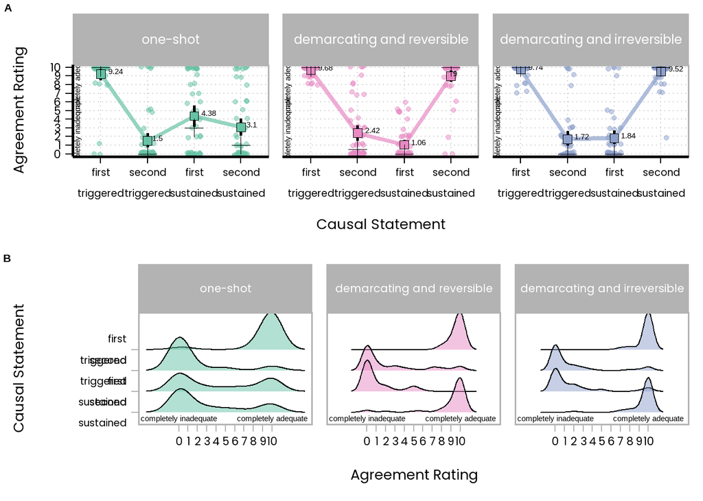

```r
library("ggpubr")

ggarrange(
  g, g2, labels = c("A", "B"),
  common.legend = TRUE, legend = "none",
  font.label = list(size = 16, color = "black", family = "Arial", face = "bold"),
  nrow = 2,
  ncol = 1
  ) -> c_plot

c_plot
```

```r
ggsave("res_squids_02.svg",width=16,height=12)
ggsave("res_squids_02.pdf",width=16,height=12)
```

# 5 Analyses

## 5.1 Mixed ANOVA

```r
library(afex)
library(emmeans)

a1 <- aov_car(rating ~ structure*entity + Error(subj_code/entity), tdata_long, anova_table = list(es = "pes"))
a1
```

```
## Anova Table (Type 3 tests)
##
## Response: rating
##             Effect           df  MSE          F  pes p.value
## 1        structure       2, 147 6.13  12.62 *** .147   <.001
## 2           entity 2.63, 386.68 9.20 258.41 *** .637   <.001
## 3 structure:entity 5.26, 386.68 9.20  29.95 *** .289   <.001
## ---
## Signif. codes:  0 '***' 0.001 '**' 0.01 '*' 0.05 '+' 0.1 ' ' 1
##
## Sphericity correction method: GG
```

Predicted interaction effect was significant-

Visualize also the obtained main effect of “structure” (reversibility)

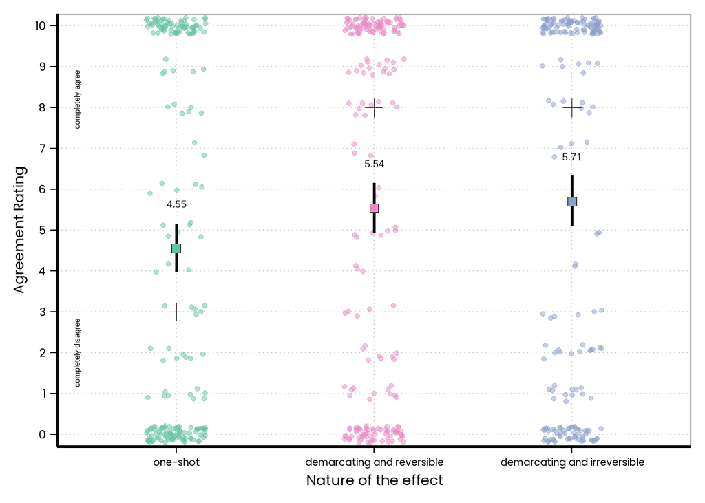

```r
tdata_sub <- tdata_long


library(see)
## first, turn sID into a factor
tdata_sub$subj_code <- factor(tdata_sub$subj_code)

pd <- position_dodge(width = 0.3)

tdata_sub$valueJitter <- jitter(tdata_sub$rating, factor = 0.01, amount = 0.004)

theme_set(theme_light(base_size = 20, base_family = "Poppins"))


g <- ggplot(tdata_sub, aes(x = structure, y = valueJitter)) +
  guides(fill=FALSE)+

  scale_y_continuous(limits = c(-0.3, 10.3), breaks=seq(0, 10, 1), expand = c(0,0)) +
  geom_jitter(aes(color = structure), alpha = 0.5, width = 0.15, height = 0.2) +
  stat_summary(aes(y = rating, group=1), fun.data = mean_cl_boot,
               geom = "errorbar", width = 0, size = 1) +
  stat_summary(aes(y = rating, group=1, fill = structure), fun.y=mean, geom="point",
               color = "black", shape = 22, size = 3, group=1, alpha = 1)+
  stat_summary(aes(y = rating,group=1), fun.y=median, geom="point", color = "black", shape = 3, size = 4,
               group=1, alpha = 1, position = position_dodge(width = 0.5))+
  labs(x = "Nature of the effect", y = "Agreement Rating") +
  scale_color_manual(name = "Strength",values=c("#66c2a5", "#e78ac3", "#8da0cb", "#a6d854"))+
  scale_fill_manual(name = "Strength",values=c("#66c2a5", "#e78ac3", "#8da0cb", "#a6d854"))+
  theme(legend.position = "none")+
  myTheme+
  theme(panel.grid.major = element_line(color = "lightgrey",
                                        size = 0.5,
                                        linetype = 'dotted'))+
  stat_summary(aes(label=round(after_stat(y),2)), fun.y=mean, geom="text", size=5,
             vjust = -6)+
  annotate("text", x = 0.5, y = 2, label = c("completely disagree"), angle = 90)+
  annotate("text", x = 0.5, y = 8.2, label = c("completely agree"), angle = 90)

g
```

Plot main effect of entity (causal statement):

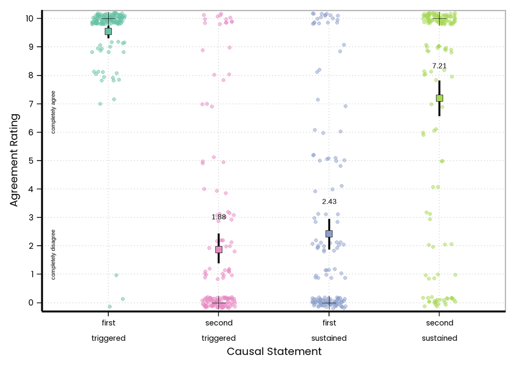

```r
tdata_sub <- tdata_long


library(see)
## first, turn sID into a factor
tdata_sub$subj_code <- factor(tdata_sub$subj_code)

pd <- position_dodge(width = 0.3)

tdata_sub$valueJitter <- jitter(tdata_sub$rating, factor = 0.01, amount = 0.004)

theme_set(theme_light(base_size = 20, base_family = "Poppins"))

g <- ggplot(tdata_sub, aes(x = entity, y = valueJitter)) +
  guides(fill=FALSE)+
  scale_y_continuous(limits = c(-0.3, 10.3), breaks=seq(0, 10, 1), expand = c(0,0)) +
  geom_jitter(aes(color = entity), alpha = 0.5, width = 0.15, height = 0.2) +
  stat_summary(aes(y = rating, group=1), fun.data = mean_cl_boot,
               geom = "errorbar", width = 0, size = 1) +
  stat_summary(aes(y = rating, group=1, fill = entity), fun.y=mean, geom="point",
               color = "black", shape = 22, size = 3, group=1, alpha = 1)+
  stat_summary(aes(y = rating,group=1), fun.y=median, geom="point", color = "black", shape = 3, size = 4,
               group=1, alpha = 1, position = position_dodge(width = 0.5))+
  labs(x = "Causal Statement", y = "Agreement Rating") +
  scale_color_manual(name = "Strength",values=c("#66c2a5", "#e78ac3", "#8da0cb", "#a6d854"))+
  scale_fill_manual(name = "Strength",values=c("#66c2a5", "#e78ac3", "#8da0cb", "#a6d854"))+
  theme(legend.position = "none")+
  annotate("text", x = 0.5, y = 1.7, label = c("completely disagree"), angle = 90)+
  annotate("text", x = 0.5, y = 6.7, label = c("completely agree"), angle = 90)+
  myTheme+
  theme(panel.grid.major = element_line(color = "lightgrey",
                                        size = 0.5,
                                        linetype = 'dotted'))+
  stat_summary(aes(label=round(after_stat(y),2)), fun.y=mean, geom="text", size=5,
             vjust = -6)

g
```

## 5.2 Contrasts

```r
library(lsmeans)
# means

ls2 <- lsmeans(a1, c("structure", "entity"))
ls2
```

```
##  structure                    entity            lsmean    SE  df lower.CL
##  one-shot                     first..triggered    9.24 0.207 147    8.832
##  demarcating and reversible   first..triggered    9.68 0.207 147    9.272
##  demarcating and irreversible first..triggered    9.74 0.207 147    9.332
##  one-shot                     second..triggered   1.50 0.455 147    0.602
##  demarcating and reversible   second..triggered   2.42 0.455 147    1.522
##  demarcating and irreversible second..triggered   1.72 0.455 147    0.822
##  one-shot                     first..sustained    4.38 0.454 147    3.483
##  demarcating and reversible   first..sustained    1.06 0.454 147    0.163
##  demarcating and irreversible first..sustained    1.84 0.454 147    0.943
##  one-shot                     second..sustained   3.10 0.389 147    2.332
##  demarcating and reversible   second..sustained   9.00 0.389 147    8.232
##  demarcating and irreversible second..sustained   9.52 0.389 147    8.752
##  upper.CL
##      9.65
##     10.09
##     10.15
##      2.40
##      3.32
##      2.62
##      5.28
##      1.96
##      2.74
##      3.87
##      9.77
##     10.29
##
## Confidence level used: 0.95
```

```r
contrasts <- emmeans(a1, ~ entity|structure)
s <- pairs(contrasts, adjust = "none")


s
```

```
## structure = one-shot:
##  contrast                              estimate    SE  df t.ratio p.value
##  first..triggered - second..triggered      7.74 0.577 147  13.416  <.0001
##  first..triggered - first..sustained       4.86 0.515 147   9.435  <.0001
##  first..triggered - second..sustained      6.14 0.451 147  13.612  <.0001
##  second..triggered - first..sustained     -2.88 0.568 147  -5.067  <.0001
##  second..triggered - second..sustained    -1.60 0.629 147  -2.543  0.0120
##  first..sustained - second..sustained      1.28 0.644 147   1.988  0.0487
##
## structure = demarcating and reversible:
##  contrast                              estimate    SE  df t.ratio p.value
##  first..triggered - second..triggered      7.26 0.577 147  12.584  <.0001
##  first..triggered - first..sustained       8.62 0.515 147  16.734  <.0001
##  first..triggered - second..sustained      0.68 0.451 147   1.508  0.1338
##  second..triggered - first..sustained      1.36 0.568 147   2.393  0.0180
##  second..triggered - second..sustained    -6.58 0.629 147 -10.457  <.0001
##  first..sustained - second..sustained     -7.94 0.644 147 -12.330  <.0001
##
## structure = demarcating and irreversible:
##  contrast                              estimate    SE  df t.ratio p.value
##  first..triggered - second..triggered      8.02 0.577 147  13.902  <.0001
##  first..triggered - first..sustained       7.90 0.515 147  15.336  <.0001
##  first..triggered - second..sustained      0.22 0.451 147   0.488  0.6265
##  second..triggered - first..sustained     -0.12 0.568 147  -0.211  0.8331
##  second..triggered - second..sustained    -7.80 0.629 147 -12.396  <.0001
##  first..sustained - second..sustained     -7.68 0.644 147 -11.927  <.0001
```

```r
confint(s, level = 0.95)
```

```
## structure = one-shot:
##  contrast                              estimate    SE  df lower.CL upper.CL
##  first..triggered - second..triggered      7.74 0.577 147  6.59990    8.880
##  first..triggered - first..sustained       4.86 0.515 147  3.84201    5.878
##  first..triggered - second..sustained      6.14 0.451 147  5.24857    7.031
##  second..triggered - first..sustained     -2.88 0.568 147 -4.00316   -1.757
##  second..triggered - second..sustained    -1.60 0.629 147 -2.84353   -0.356
##  first..sustained - second..sustained      1.28 0.644 147  0.00742    2.553
##
## structure = demarcating and reversible:
##  contrast                              estimate    SE  df lower.CL upper.CL
##  first..triggered - second..triggered      7.26 0.577 147  6.11990    8.400
##  first..triggered - first..sustained       8.62 0.515 147  7.60201    9.638
##  first..triggered - second..sustained      0.68 0.451 147 -0.21143    1.571
##  second..triggered - first..sustained      1.36 0.568 147  0.23684    2.483
##  second..triggered - second..sustained    -6.58 0.629 147 -7.82353   -5.336
##  first..sustained - second..sustained     -7.94 0.644 147 -9.21258   -6.667
##
## structure = demarcating and irreversible:
##  contrast                              estimate    SE  df lower.CL upper.CL
##  first..triggered - second..triggered      8.02 0.577 147  6.87990    9.160
##  first..triggered - first..sustained       7.90 0.515 147  6.88201    8.918
##  first..triggered - second..sustained      0.22 0.451 147 -0.67143    1.111
##  second..triggered - first..sustained     -0.12 0.568 147 -1.24316    1.003
##  second..triggered - second..sustained    -7.80 0.629 147 -9.04353   -6.556
##  first..sustained - second..sustained     -7.68 0.644 147 -8.95258   -6.407
##
## Confidence level used: 0.95
```

The planned contrasts from the list above are ” first..caused - second..caused” in both “irreversible” and “reversible”. Both are significant.

Get effect standardized effect sizes for the contrasts

```r
library(dplyr)

tdata_long %>%
  group_by(structure, entity) %>%
  summarise_at(vars(rating), list(name=sd))
```

```
## # A tibble: 12 × 3
## # Groups:   structure [3]
##    structure                    entity                name
##    <fct>                        <fct>                <dbl>
##  1 one-shot                     "first \ntriggered"  2.33
##  2 one-shot                     "second \ntriggered" 3.14
##  3 one-shot                     "first \nsustained"  4.33
##  4 one-shot                     "second \nsustained" 3.91
##  5 demarcating and reversible   "first \ntriggered"  0.621
##  6 demarcating and reversible   "second \ntriggered" 3.41
##  7 demarcating and reversible   "first \nsustained"  1.78
##  8 demarcating and reversible   "second \nsustained" 2.36
##  9 demarcating and irreversible "first \ntriggered"  0.751
## 10 demarcating and irreversible "second \ntriggered" 3.08
## 11 demarcating and irreversible "first \nsustained"  2.99
## 12 demarcating and irreversible "second \nsustained" 1.33
```

The planned contrasts compare the maintainer ratings for the second cause in “stable”, “unstable”, and “reversible”. It must be looked up from the long list of contrasts below:

```r
contrasts <- emmeans(a1, ~ entity*structure)
s <- pairs(contrasts, adjust = "none")


s
```

```
##  contrast
##  (first..triggered one-shot) - (second..triggered one-shot)
##  (first..triggered one-shot) - (first..sustained one-shot)
##  (first..triggered one-shot) - (second..sustained one-shot)
##  (first..triggered one-shot) - first..triggered demarcating and reversible
##  (first..triggered one-shot) - second..triggered demarcating and reversible
##  (first..triggered one-shot) - first..sustained demarcating and reversible
##  (first..triggered one-shot) - second..sustained demarcating and reversible
##  (first..triggered one-shot) - first..triggered demarcating and irreversible
##  (first..triggered one-shot) - second..triggered demarcating and irreversible
##  (first..triggered one-shot) - first..sustained demarcating and irreversible
##  (first..triggered one-shot) - second..sustained demarcating and irreversible
##  (second..triggered one-shot) - (first..sustained one-shot)
##  (second..triggered one-shot) - (second..sustained one-shot)
##  (second..triggered one-shot) - first..triggered demarcating and reversible
##  (second..triggered one-shot) - second..triggered demarcating and reversible
##  (second..triggered one-shot) - first..sustained demarcating and reversible
##  (second..triggered one-shot) - second..sustained demarcating and reversible
##  (second..triggered one-shot) - first..triggered demarcating and irreversible
##  (second..triggered one-shot) - second..triggered demarcating and irreversible
##  (second..triggered one-shot) - first..sustained demarcating and irreversible
##  (second..triggered one-shot) - second..sustained demarcating and irreversible
##  (first..sustained one-shot) - (second..sustained one-shot)
##  (first..sustained one-shot) - first..triggered demarcating and reversible
##  (first..sustained one-shot) - second..triggered demarcating and reversible
##  (first..sustained one-shot) - first..sustained demarcating and reversible
##  (first..sustained one-shot) - second..sustained demarcating and reversible
##  (first..sustained one-shot) - first..triggered demarcating and irreversible
##  (first..sustained one-shot) - second..triggered demarcating and irreversible
##  (first..sustained one-shot) - first..sustained demarcating and irreversible
##  (first..sustained one-shot) - second..sustained demarcating and irreversible
##  (second..sustained one-shot) - first..triggered demarcating and reversible
##  (second..sustained one-shot) - second..triggered demarcating and reversible
##  (second..sustained one-shot) - first..sustained demarcating and reversible
##  (second..sustained one-shot) - second..sustained demarcating and reversible
##  (second..sustained one-shot) - first..triggered demarcating and irreversible
##  (second..sustained one-shot) - second..triggered demarcating and irreversible
##  (second..sustained one-shot) - first..sustained demarcating and irreversible
##  (second..sustained one-shot) - second..sustained demarcating and irreversible
##  first..triggered demarcating and reversible - second..triggered demarcating and reversible
```

[output cut: 79 more lines]

```
##     -7.94 0.644 147 -12.330  <.0001
##     -8.68 0.499 147 -17.410  <.0001
##     -0.66 0.642 147  -1.028  0.3058
##     -0.78 0.642 147  -1.216  0.2261
##     -8.46 0.598 147 -14.158  <.0001
##     -0.74 0.440 147  -1.681  0.0949
##      7.28 0.598 147  12.171  <.0001
##      7.16 0.598 147  11.983  <.0001
##     -0.52 0.550 147  -0.946  0.3458
##      8.02 0.577 147  13.902  <.0001
##      7.90 0.515 147  15.336  <.0001
##      0.22 0.451 147   0.488  0.6265
##     -0.12 0.568 147  -0.211  0.8331
##     -7.80 0.629 147 -12.396  <.0001
##     -7.68 0.644 147 -11.927  <.0001
```